# Metabolomics Data Matrix

Pietro Franceschi | pietro.franceschi@fmach.it

## Many variables in many samples

As in all *omic* experiments, a metabolomic assay measures a large number of **variables** (properties) in a (hopefully) reasonably large number of **samples**.

⚠️ **Question:**  
… what are the variables …

1. In a targeted metabolomics investigation?
2. In an untargeted MS based metabolomics analysis?
3. In an untargeted NMR based metabolomics assay?

## Number of variables | place your guess

- Targeted metabolomics investigation
  - from 10 to 300
- Untargeted metabolomics investigation
  - from 1000 to 30000

## Data Matrix

[figure not shown]

## The goal of data analysis

⚠️ **Goal:**  
The objective of data analysis is to find **“organization”** inside the matrix

Our organization should also be statistically robust: if someone redid my experiment, the results should be the same 😉

## Organization: Correlations

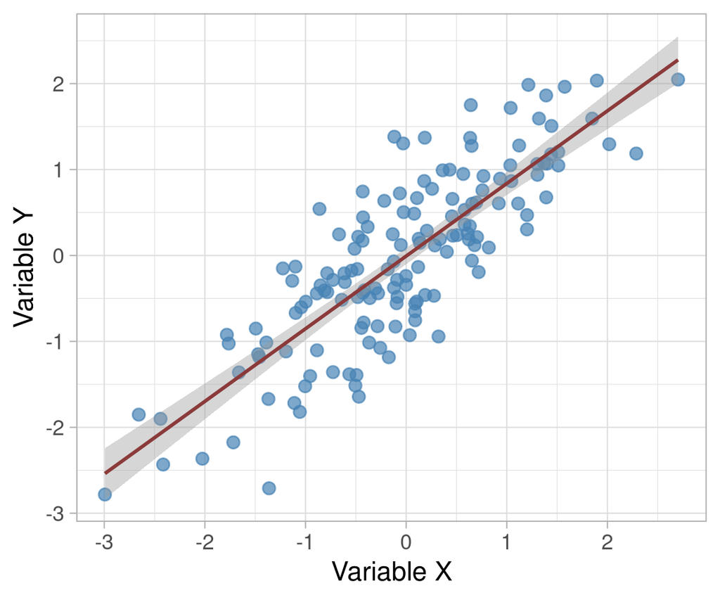

## Organization: Biomarkers

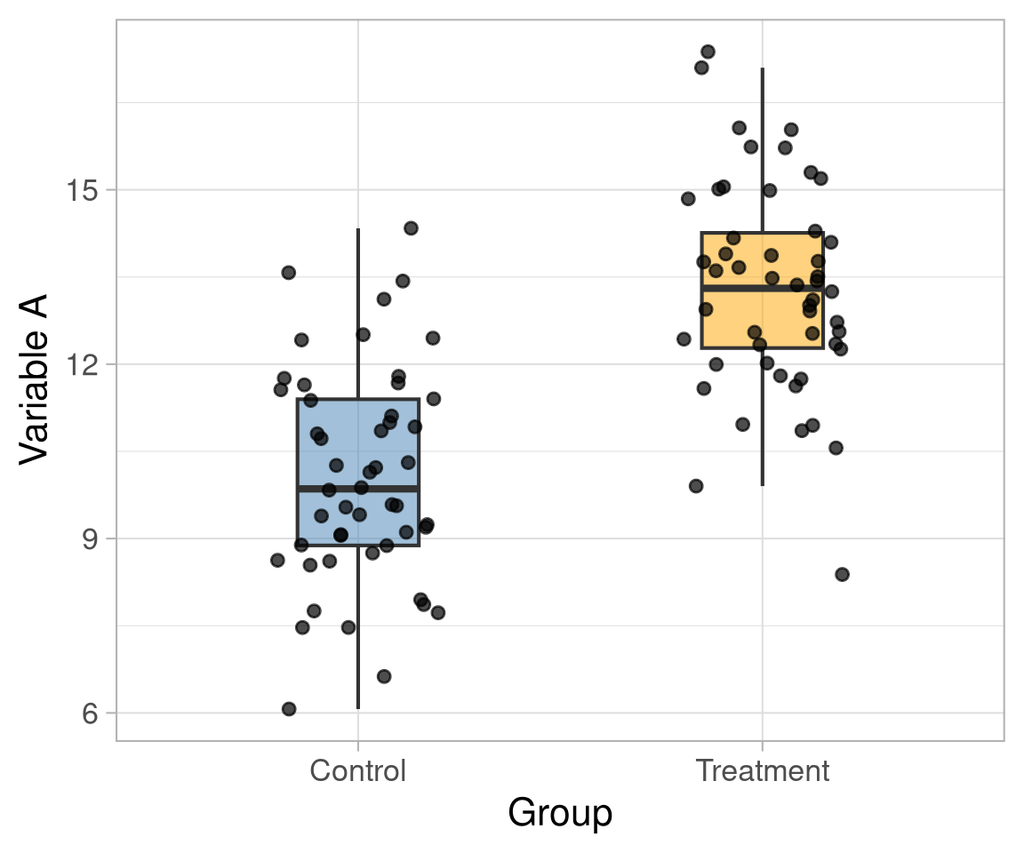

# Data Matrices: facts

## Variables are not independent

- Biological relations
- Chemical/Analytical reasons

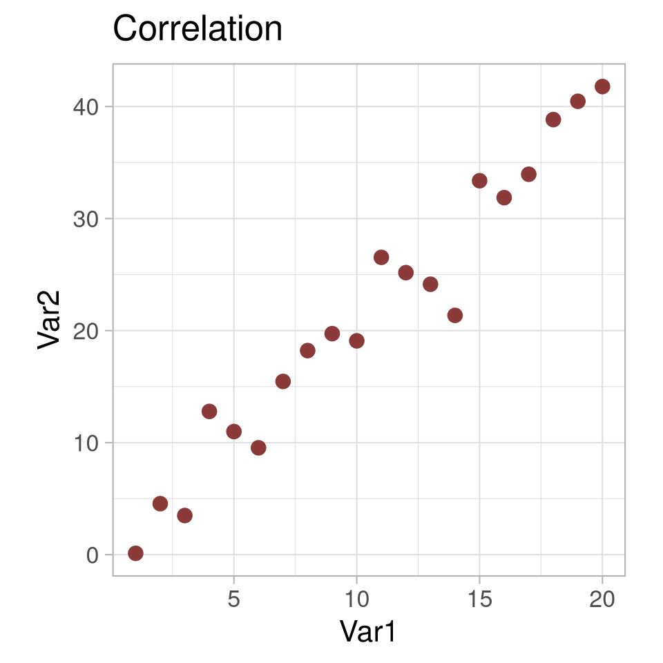

## Analytical vs biological correlation

⚠️ **Important:**  
Analytical correlation is always stronger than the biological one!

The correlation structure of your matrix is often not really informative about biology

## Rows (samples) are often dependent

The design of the study can result in a multilevel hierarchical structure of the samples which violates independence. In other words some samples are “by construction” associated and share something in common

**Examples**

1. Repeated measures of the same individual
2. Subpopulations
3. Different sites, different days, …

## Data Matrix size

In the typical “happy” statistical context, the number of variables we measure is smaller than the number of samples.

In *omics* the number of variables normally exceeds the number of samples

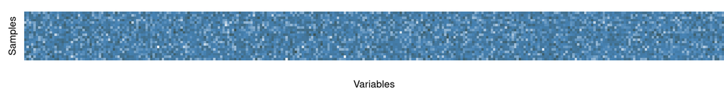

FAT DATA MATRIX

# Analyzing data matrices

## Univariate approach

The **Univariate** approach considers each variable separately and applies “standard” statistical tools to spot the more **interesting** variables

1. Statistical testing
2. Linear modeling (`lm`, `glm`, …)
3. ANOVAs
4. Hierarchical Modeling

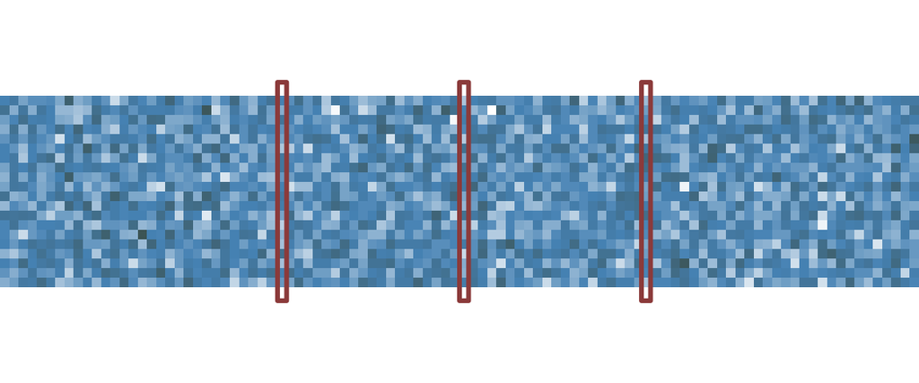

## Univariate: pros and cons

**PRO** 😀

1. Statistical modeling is there!
2. Interpretable by construction

**CONS** 😞

1. Multiple testing
2. The structure of the data creates redundancy
3. Assumptions for parametric (and non parametric) approaches are often not fulfilled

## Where is the problem: Multiple testing

- We measure many variables (features, metabolites) in the same set of samples
- We run a battery of statistical tests looking for the significance of what we see in the individual variables
- **We ask ourselves if at least one test is significant in the overall set of tests**

We run individual tests, but we have a question about the full set of variables …

## Multivariate approach

Each sample is represented as a point in the multidimensional variable space. The dataset is a **cloud** of points in that space.

The size of the space equals the number of variables we are measuring. **Multivariate methods** (PCA, PLS, ASCA, …) are able to exploit the correlation between the variables to highlight/extract the organization of the data

[figure not shown]

## Why multivariate …

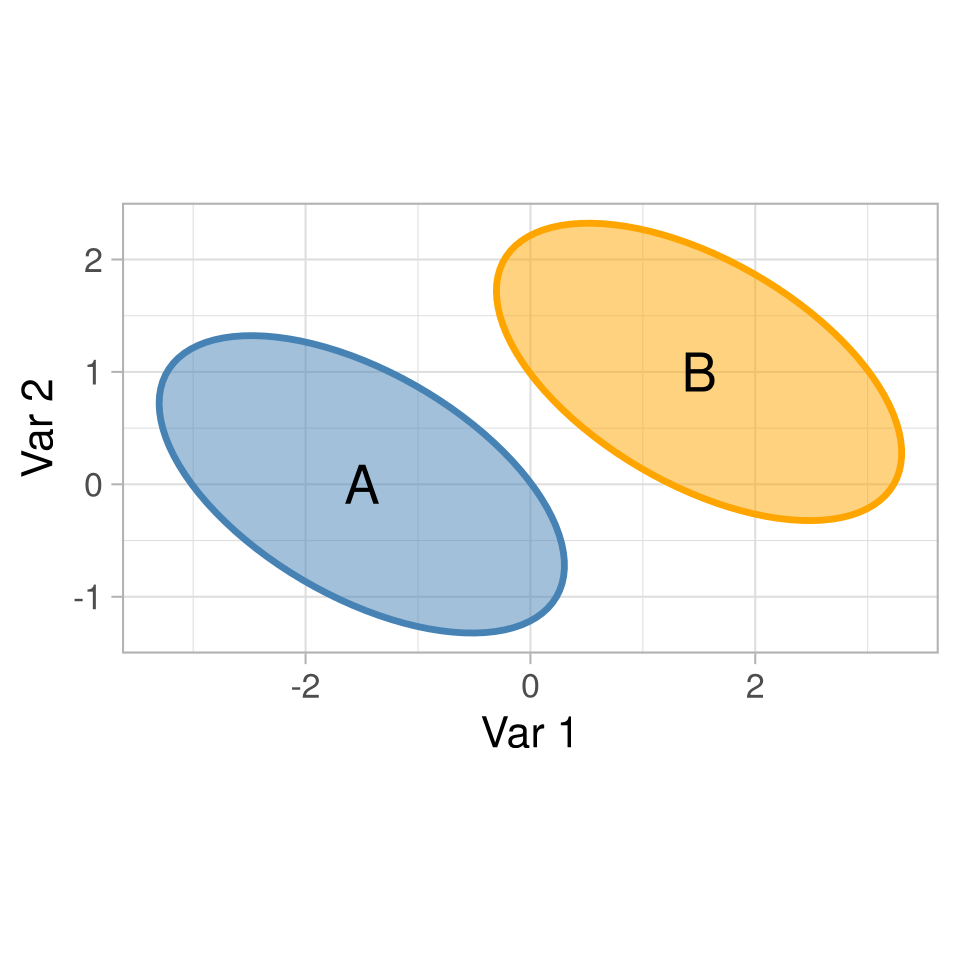

Group separation is clearer in the 2D space …

## Multivariate: pros and cons

**PRO** 😀

1. Potentially more powerful
2. Explicit use of variable correlation
3. No issues with multiple testing

**CONS** 😞

1. Chance correlations in fat matrices
2. Empty space
3. Difficult to embed hierarchical structure

## The problem: the curse of dimensionality

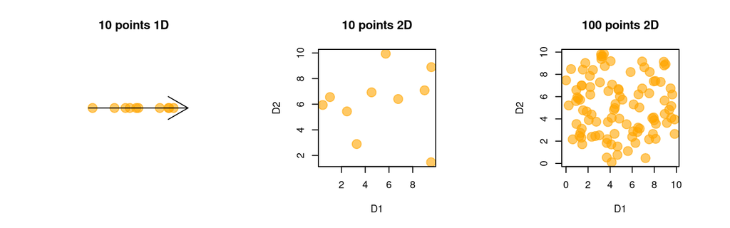

1. To fill the space, the number of points does not grow linearly with the number of dimensions
2. Already with 10 samples the 2D plot looks empty

Can you imagine 20 samples in 10000 dimensions? 😉